# 2.3. Predictability

소챕터 2.2에서는 Martingale과 Submartingale에 대해 살펴보았다. Martingale의 condition 중 4번째인 Martingale Property의 의미는 (Condition 4.2의 의미) 결국 현재$(n)$ 갖고 있는 정보를 통해 추정하는 미래$(n+1)$의 기대값 $E(X_{n+1}|\mathcal{F}_n)$은 현재의 값과 같다는 것이다, i.e., $E(X_{n+1}|\mathcal{F}_n)=X_n$. 그런데 Submartingale은 미래에 기대되는 값이 현재보다 더 나은 상황을 의미한다. 이번 챕터에선 궁극적으로 다음 챕터에서 배울 Doob-Meyer decomposition을 위한 Predictability에 대해 알아보고 학습할 것이다.

##### Definition (predictability)

Let $\{Y(t)\}$ be a family of random variables, and $\{\mathcal{F}_t\}$ be a filtration (with the same index set). Then, “$\{Y(t)\}$ is predictable with respect to $\{\mathcal{F}_t\}$” essentially means that
$$Y(t)\in \mathcal{F}_{t-}.$$

- Predictability의 의미는 시점 $t-$에서 $\epsilon$만큼 이후(아주 조금 후)의 값은 현재의 값과 큰 차이가 나지 않게 예측이 가능하다는 의미이다. 즉 $\mathcal{F}_{t-}$정보가 있을 때, $Y(t)$는 더이상 random variable이 아니다. 아래의 Fact 1, Fact 2를 통해 충분히 보충 설명한다.

##### Fact 1

All left-continuous adapted processes are predictable.

- Note that this is very intuitive, given our definition.

In the case of a process in discrete time, predictability is the condition
$$Y_n\in \mathcal{F}_{n-1} \mbox{ }\mbox{ }\mbox{ }\mbox{ for all }n.$$

- 즉 $t$ 시점의 정보는 정의 $Y(t)\in \mathcal{F}_{t-}$에 따라 $t-$시점의 값으로 predict할 수 있기 때문에 이는 left continuity로 설명된다.
- 아래의 이미지와 같이 left-continuous한 counting process를 생각해보자. 여기서 jump가 이루어지는 시점을 $t-$라고 하자. 또한 현재 $\mathcal{F}_{t-}$까지의 정보를 우리가 갖고 있을 때(left-continuous adapted) 당연히 $t$시점의 값 $Y(t)$는 현재 주어진 정보에서 Predict하다, i.e., $Y_n\in \mathcal{F}_{n-1}$. 때문에 All left-continuous adapted processes are predictable하다.

[figure not shown]

##### Fact 2

Any process that is both a martingale and is *finite variation* predictable must be constant

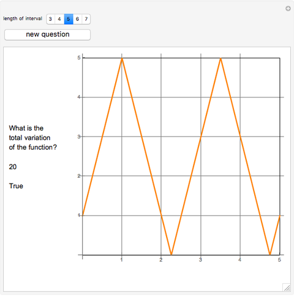

- 즉 Fact 2 *Any process that is both a martingale and is finite variation predictable must be constant*의 의미는 다음과 같다
  - Predictabilility의 정의에 의해 $Y_t\in \mathcal{F}_{t-}$이다. 즉 $\mathcal{F}_{t-}$의 정보가 given되어있을 때 $Y_t$는 더이상 random이 아니다 (Martingale에서는 random variable which is $\mathcal{F}_{t-}$-measurable).
  - Martingale property에 의해 $E(Y_t|\mathcal{F}_{t-})=Y_t$이다. 또한 $Y_{t+}=E(Y_{t+}|\mathcal{F}_{t})=E(E(Y_{t+}|\mathcal{F}_{t})|\mathcal{F}_{t-})=E(E(Y_{t+}|\mathcal{F}_{t-})|\mathcal{F}_{t})=E(Y_t|F_{t})=Y_t$이다. 즉, $\epsilon$만큼 계속 늘려나간다고 생각한다면 Martingale $(Y_t, \mathcal{F}_t)$는 constant이다.

back